# Experimental Sociology - Week 06

- Show All Code
- Hide All Code
- View Source

Evolutionary ABMs: Complex Simulations

Published

2025-05-09

# 🤖 Evolutionary ABMs: Complex Simulations

Welcome to a new chapter! As promised, this week we’ll shift our focus from building agent-based models (ABMs) to **analyzing** them. We’ll introduce only a few new lines of code — just enough to introduce the possibility of *errors* — and explore how such disruptions can influence evolutionary dynamics.

To support this analytical focus, I’ve also included the code we developed during our last in-class session. In particular, this includes **two different versions of how `model$mu_rnd` is interpreted and handled**, which allows us to investigate how random mutation affects the long-term composition of strategies.

Although the **core mechanics** of the ABM remain unchanged, I’ve overhauled the code that handles **data collection and output**, especially in the following functions: `summarise_strategies()`, `run_sequence()`, `get_data_replication()`, `get_data_simulation()`.

These changes are purely about **what data we extract and how we structure it** — not how agents interact or learn. When you run a simulation now, you’ll receive **three main data frames**:

1. `df_population`: Contains summary-level metrics for the *entire population*, such as average fitness, overall cooperation rate, and diversity indicators at each time step.
2. `df_strategies`: Provides *strategy-level metrics*, such as the fitness and population share of each individual strategy over time.
3. `df_final_worlds`: Were all information of the final worlds of all replications are stored.

In addition, i had to fix a bug. I forgot to set the fitness to 0 at the beginning of each step. To keep things organized, I created a new folder for this week’s material: **`abm-pd2/`**.

**Note**

You can [download the complete code here](https://github.com/SGrehl/SGrehl.github.io/tree/main/data/abm-pd2).

## 🎯 Learning Goals

By the end of this chapter, you will be able to:

1. **Deepen your understanding** of how repeated games evolve in a population over time
2. **Distinguish different types of mistakes** in ABMs
3. **Interpret simulation outputs** using structured data frames designed for strategy- and population-level analysis
4. **Formulate hypotheses** about robustness, equilibrium, and convergence under varying model assumptions

# Analysis

Let’s now reap the rewards of our work and analyze the dynamics of our simulation. We’ll start where we left off in the last in-class session, comparing **two different interpretations** of `model$mu_rnd`, and explore how they behave across a range of mutation rates.

We define a simulation where we vary both:

- Whether the number of mutators is fixed or randomly determined
- The random mutation rate (`mu_rnd`)

```r
simulation  <- list(
  model = "baseline_very_long",         # 2500 rounds
  replications = 15,
  tbl_parameter = expand.grid(
    mutators_n_fixed = c(TRUE, FALSE),
    mu_rnd = c(0.2, 0.1, 0.05, 0.01, 0.001)
  ),
  master_seed  = 42,
  max_cores    = 15
)

library(tidyverse)
```

If we run this:

```r
# Note: You can run this simulation yourself using run_simulation(simulation), though we pre-load results here for performance.
# results <- run_simulation(simulation)
results <- readRDS("../data/abm-pd2/week06_results_01.rds")
```

Now, we define a plotting function to visualize how the average fitness of the population evolves over time, with confidence intervals based on replications:

```r
library(rlang)

plot_avg_fitness <- function(df,
                             group_var,
                             replications = 1 # on how many replications is
                             ) {
  # try to fetch the number of replications in the data frame
  if (!is.null(results$df_population$replications)) {
    replications = max(results$df_population$replications)
  }

  # get the group_var
  group_var <- enquo(group_var)

  df |>
    mutate(
      ci_lower = pop_fit_mean - 1.96 * (pop_fit_sd / sqrt(replications)),
      ci_upper = pop_fit_mean + 1.96 * (pop_fit_sd / sqrt(replications))
    ) |>
    ggplot(aes(x = step,
               y = pop_fit_mean,
               colour = factor(!!group_var),
               fill   = factor(!!group_var))) +
    geom_line() +
    geom_ribbon(aes(ymin = ci_lower, ymax = ci_upper),
                alpha = 0.20, colour = NA) +
    labs(
      title = "Average population fitness over time",
      x = "Time step",
      y = "Average fitness",
      colour = as_name(group_var),
      fill   = as_name(group_var)
    ) +
    theme_minimal()
}
```

We now generate two plots — one for each interpretation of `mu_rnd`:

**Show R Code (Plot)**

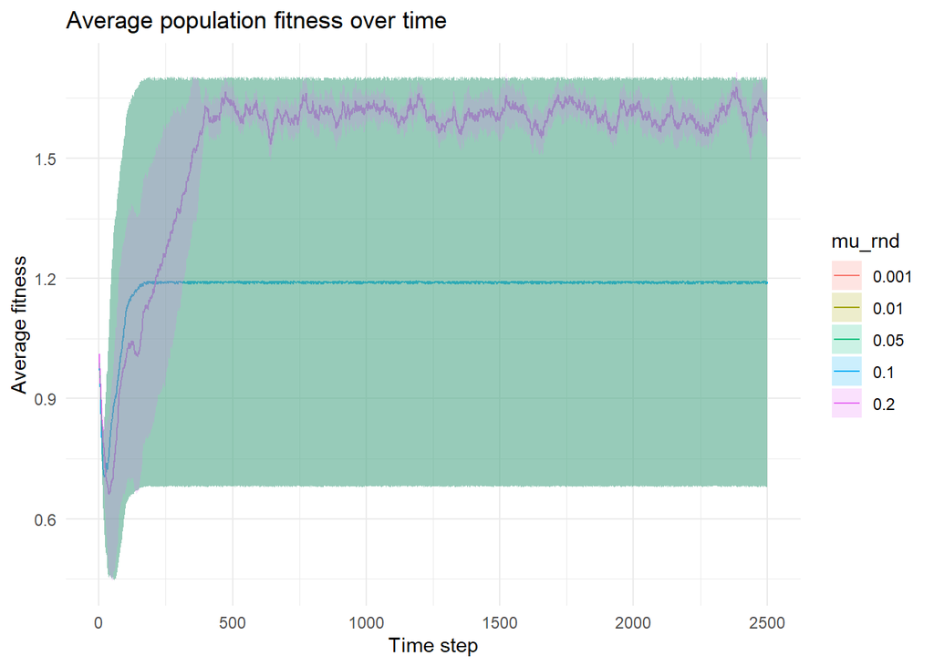

Figure 1: Average population fitness over t for diffrent random mutation rates with fixed number of mutators.

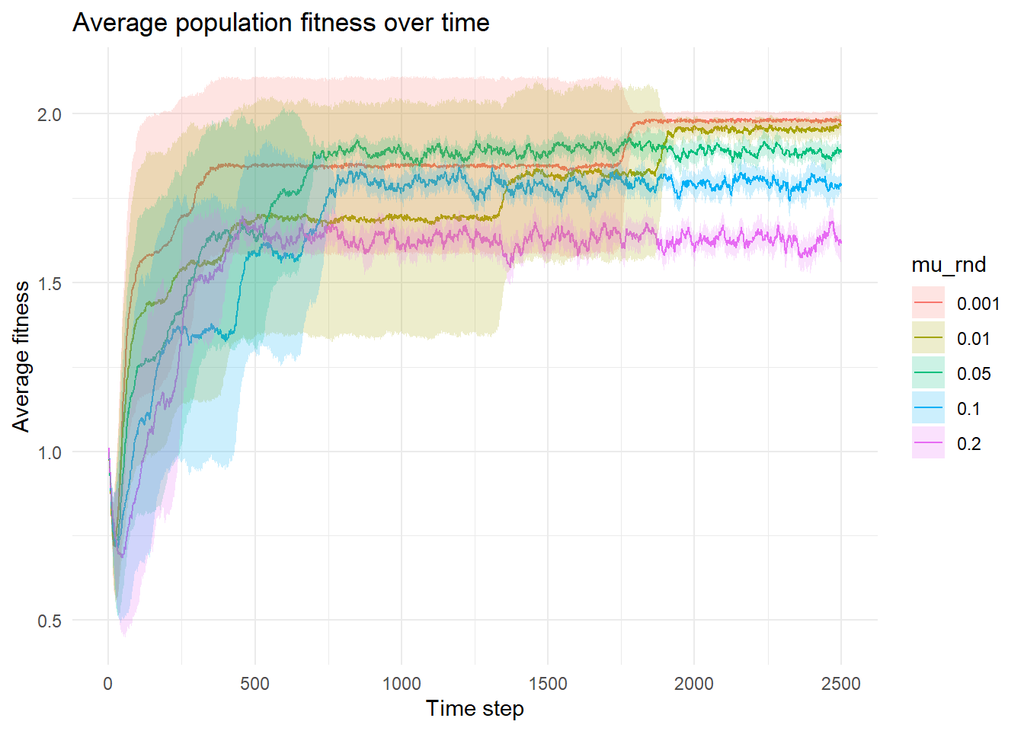

Figure 2: Average population fitness over t for diffrent random mutation rates with flexible number of mutators

```r
# plot 1
plot_avg_fitness(results$df_population |> filter(mutators_n_fixed == TRUE),
                 mu_rnd)
# plot 2
plot_avg_fitness(results$df_population |> filter(mutators_n_fixed == FALSE),
                 mu_rnd)
```

**Caution**

**Pause for a moment before reading on.** Write down everything the graphs tell you at first glance: first, describe exactly what you see; next, jot down any ideas about what those patterns might mean.

Figure 1: **Fixed Number of Random Mutators**

In the fixed mutator setting, values of `mu_rnd ≤ 0.1` behave identically. Why? Because with 100 agents and `mu = 0.05`, 5 agents update each round — and when `mu_rnd ≤ 0.1`, **no agent is selected to mutate randomly**. As a result, the evolutionary process becomes **purely path-dependent**: only the initial strategy distribution determines the final outcome. This is why we see a high variability across these replications, likely due to worlds dominated either by *Grim Trigger* **(GT)** or *Always Defect* **(aD)**.

Only with `mu_rnd = 0.2` does random mutation occur (1 agent per step), leading to many worlds were cooperative strategies are dominating — but still only reaching around 70% of the population.

Figure 2: **Random Number of Random Mutators**

In contrast, when the number of mutators is **proportional** to `mu_rnd`, each value of this parameter leads to **qualitatively different dynamics**. At the high end, when `mu_rnd = 0.2`, a large share of agents mutate randomly in every time step. This high mutation pressure continuously disrupts emerging cooperation, resulting in lower average fitness and preventing the system from settling into a highly cooperative equilibrium.

As we reduce `mu_rnd`, the situation improves markedly. With **fewer agents mutating** each round, cooperative strategies have a chance to spread and stabilize. The **average population fitness steadily increases**, reaching its highest values when `mu_rnd = 0.001`. In these low-mutation environments, strategies like Grim Trigger are able to dominate without being frequently replaced by inferior random alternatives. This can also be seen in the OLS:

```r
summary(lm(pop_fit_mean ~ mu_rnd, data = results$df_population |> filter(mutators_n_fixed == FALSE)))
```

```
Call:
lm(formula = pop_fit_mean ~ mu_rnd, data = filter(results$df_population,
    mutators_n_fixed == FALSE))

Residuals:
     Min       1Q   Median       3Q      Max
-1.08489 -0.06242  0.06711  0.13095  0.18709

Coefficients:
             Estimate Std. Error t value Pr(>|t|)
(Intercept)  1.804828   0.002705  667.29   <2e-16 ***
mu_rnd      -1.245264   0.026370  -47.22   <2e-16 ***
---
Signif. codes:  0 '***' 0.001 '**' 0.01 '*' 0.05 '.' 0.1 ' ' 1

Residual standard error: 0.2148 on 12498 degrees of freedom
Multiple R-squared:  0.1514,    Adjusted R-squared:  0.1513
F-statistic:  2230 on 1 and 12498 DF,  p-value: < 2.2e-16
```

However, this improvement is only visible because we ran the simulation for **sufficiently long** — in our case, 2500 steps. Had we stopped the simulation earlier, for example after 1000 steps, we might have mistakenly concluded that `mu_rnd = 0.05` leads to the best results, since lower values hadn’t yet had enough time to stabilize into cooperative states.

This highlights a fundamental trade-off in evolutionary modeling: **lower mutation rates promote long-term stability and higher fitness**, but they also **slow down the adaptive process**. Worlds with very low `mu_rnd` evolve toward optimal states more slowly — they take longer to escape initial randomness or suboptimal configurations. Conversely, higher mutation rates increase adaptability in the short run but often prevent the emergence of stable, high-fitness structures. Finding the right balance depends on whether your focus is on **short-term responsiveness** or **long-term stability**.

Now, let’s take a closer look at the **final state** of the simulated worlds. While average population fitness gives us a sense of overall performance, it doesn’t tell us *which strategies* are driving those outcomes. To explore this, we’ll write a small helper function that summarizes **which strategies survived** and how well they performed on average.

This function will group agents by their strategy at the end of the simulation, calculate each strategy’s **population share**, and compute their **mean fitness**. This allows us to identify not just the most common strategies, but also the most effective ones.

Let’s implement it:

```r
# can be found in functions_anaylsis.R
summarise_strategies_final <- function(df, top_n = 10) {
  # 1) get the strategies
  df <- df |>
    mutate(
      strat_id = do.call(paste0, pick(rep:fitness, -c(rep, fitness)))
    )

  # 2) calculate mean fitness
  df |>
    group_by(strat_id) |>
    summarise(
      share        = n() / nrow(df),
      fitness_mean = mean(fitness),
      .groups      = "drop"     ) |>
    arrange(desc(fitness_mean)) |>
    slice_head(n = top_n)
}
```

## Efficient Equilibria

Let’s explore the first replication of the world with `mu_rnd = 0.001` and `mutators_n_fixed = FALSE`:

```r
summarise_strategies_final(results$df_final_worlds |> filter(mutators_n_fixed == FALSE, mu_rnd == 0.001, rep == 1))
```

```
# A tibble: 1 × 3
  strat_id share fitness_mean
  <chr>    <dbl>        <dbl>
1 10001        1            2
```

We see that only Grim Trigger survives — yielding the maximum possible fitness of 2. This occurs in 9 of 15 replications. In two others, we see similar cooperative strategies (Tit-for-Tat) dominating the world. In some worlds, multiple cooperative strategies coexist:

```r
summarise_strategies_final(results$df_final_worlds |> filter(mutators_n_fixed == FALSE, mu_rnd == 0.001, rep == 5))
```

```
# A tibble: 2 × 3
  strat_id share fitness_mean
  <chr>    <dbl>        <dbl>
1 10001     0.97            2
2 10011     0.03            2
```

In this particular world, we observe that **two cooperative strategies have survived**.[^1] This outcome is not surprising: once **defective strategies disappear**, there is **no longer any evolutionary pressure** between the remaining cooperative strategies as they yield the same fitness.

From the perspective of **evolutionary game theory**, we would describe such a situation as a **Lyapunov stable equilibrium**. It is stable in the sense that, although multiple strategies may coexist, **none has an incentive or evolutionary advantage to replace the other**, as long as no external disturbances (like defectors) re-enter the system.

More generally, **any cooperative strategy** could enter this world without being selected against. This is because strategies like Grim Trigger (or any similarly cooperative rule) are **not evolutionarily stable strategies (ESS)** when faced with other cooperative strategies — as we discussed in Week 4. They can coexist without one outcompeting the other.

This sets the stage for a phenomenon known as **random drift**: when multiple strategies have **equal fitness**, their relative share in the population can shift purely by chance. Over time, some strategies may come to dominate not because they are better, but because of **stochastic fluctuations** in mutation and imitation. For example, in this world, a fully cooperative strategy like `11111` could easily enter and persist.

From a **social science perspective** we would say this type of equilibrium is **efficient**, in the sense that it produces **the maximum collective benefit** through full cooperation.

## Inefficient equilibria: When Suboptimal Strategies Survive

Now lets take a look at another replication of this simulation, namely replication 2:

```r
summarise_strategies_final(results$df_final_worlds |> filter(mutators_n_fixed == FALSE, mu_rnd == 0.001, rep == 2))
```

```
# A tibble: 1 × 3
  strat_id share fitness_mean
  <chr>    <dbl>        <dbl>
1 01001        1          1.8
```

In this replication, we observe a world dominated by a strategy that **defects in the first round**, but then **cooperates** if both actors either cooperated or defected. Since all agents behave this way, the result is that everyone defects in the first round, followed by mutual cooperation in subsequent rounds. The strategy scores reasonably well because it sacrifices only the benefits of the first round — we’ll call it *Probe and Peace* (**PP**).

However, this strategy is clearly **inefficient**. A world populated by GT would achieve a higher overall fitness — in fact, the maximum possible average fitness of 2. In contrast, PP worlds settle for slightly less, simply because they miss out on the first round of potential cooperation. This raises a natural question: **Why hasn’t GT taken over this world?** Is this outcome merely the result of GT not being present in the initial population, and failing to emerge by chance through random mutation? And if GT does appear — even just once — can it gradually outcompete PP and shift the system toward a more efficient system?

To investigate this, we’ll recreate the PP-dominated world under controlled conditions. In the original simulation, the number of rounds in each interaction was drawn randomly from a range, which introduces noise into fitness comparisons. For this experiment, we’ll fix the number of rounds to exactly 15, so that each pairwise interaction is directly comparable. This allows us to observe more precisely how well GT performs relative to PP — and whether it stands a chance of invading and eventually dominating this seemingly suboptimal world.

Let’s simulate it. We start with a world full of PP strategies and one single GT agent:

```r
model <- list(
  # --- single game ---
  b = 3,                         # the benefit if the other cooperates
  c = 1,                         # the cost to cooperate
  # --- world generation ---
  n = 100,                       # number of agents
  memory = 1,                    # how many rounds can actors remember?
  expected_rounds = c(15, 15),   # an interval how many rounds of a games are to expect
  seed = 42+2,                   # our starting seed for the 2. replication
  # --- step ---
  mu = 0.05,                     # 5 % of our agents mutate per time step (i.e. 5 agents)
  mu_rnd = 0.001,                # 0.1% of the changers are purely random
  w  = 5,                        #
  mutators_n_fixed = FALSE,
  max_t = 2500                   # number of maximal rounds
)

source("../data/abm-pd2/functions_sequence.R", chdir = TRUE)

world <- init_world(model)
# change all strategies to PP (01001)
world$strat_mat[,] <- rep(c(0,1,0,0,1), each = nrow(world$strat_mat))
# change a single strategy to GT (10001)
world$strat_mat[1,] <- c(1,0,0,0,1)
# calculate the fitness values
result <- run_step_fast_cpp(world, model)
# show the fitness values
summarise_strategies(world)
```

```
# A tibble: 2 × 3
  strat_id share fitness_mean
  <chr>    <dbl>        <dbl>
1 01001     0.99         1.85
2 10001     0.01         1.33
```

As we can see from the results, GT performs significantly worse than PP in this world (PP is ESS against GT). If a single GT agent were to emerge through mutation, it would **not** have a fitness advantage — in fact, it’s likely that it would be **eliminated** quickly through imitation dynamics.

However, since `mutators_n_fixed==FALSE` in theory more than one agent at one time step might randomly mutate into GT. If that happens — and if the number of GT agents crosses a certain threshold — it’s possible that GT could begin to compete more effectively and eventually spread. So, let’s test this: we’ll simulate a series of controlled scenarios in which the **number of GT agents gradually increases**, and observe how their fitness compares to that of the remaining PP agents. This will allow us to determine whether there’s a tipping point — a critical mass of GT agents — beyond which GT could start to dominate the population.

```r
world <- init_world(model)

# change all strategies to PP (01001)
world$strat_mat[,] <- rep(c(0,1,0,0,1), each = nrow(world$strat_mat))

# the number of maximum GT strategies
GT_max = 10

df_fit <- data.frame(
  n_GT       = 1:GT_max,
  fitness_GT = numeric(GT_max),   # agent 1’s fitness each run
  fitness_PP = numeric(GT_max)    # agent 100’s fitness each run
)

# Run the simulation 10 times
for (i in 1:GT_max) {
  # add another GT
  world$strat_mat[i,] <- c(1,0,0,0,1)

  ## run the step
  result <- run_step_fast_cpp(world, model)

  ## store the two fitness values
  df_fit$fitness_GT[i] <- result$agents[1,   "fitness"]
  df_fit$fitness_PP[i] <- result$agents[100, "fitness"]
}

df_fit
```

```
   n_GT fitness_GT fitness_PP
1     1   1.333333   1.845118
2     2   1.340067   1.823569
3     3   1.346801   1.802020
4     4   1.353535   1.780471
5     5   1.360269   1.758923
6     6   1.367003   1.737374
7     7   1.373737   1.715825
8     8   1.380471   1.694276
9     9   1.387205   1.672727
10   10   1.393939   1.651178
```

The results show: **even with more GT agents**, PP still outperforms them. This means it is very unlikely that in this world GT overcomes PP.[^2]

But what about other strategies — could one of them successfully invade a PP-dominated world? For instance, what if a few aD agents were introduced? Unlike GT, aD doesn’t rely on conditional cooperation and might be able to exploit the predictability of PP’s behavior.

To explore this possibility, let’s repeat the same trail—this time gradually increasing the number of aD agents in an otherwise PP-populated world. We’ll observe how the fitness of aD compares to PP as its population share increases. Could aD gain a foothold and eventually take over where GT failed?

```r
world <- init_world(model)
world$strat_mat[,] <- rep(c(0,1,0,0,1), each = nrow(world$strat_mat))

# the number of maximum aD strategies
aD_max = 10

df_fit <- data.frame(
  n_aD       = 1:aD_max,
  fitness_aD = numeric(aD_max),   # agent 1’s fitness each run
  fitness_PP = numeric(aD_max)    # agent 100’s fitness each run
)

# Run the simulation 10 times
for (i in 1:10) {
  # add another GT
  world$strat_mat[i,] <- c(0,0,0,0,0)

  ## run the step
  result <- run_step_fast_cpp(world, model)

  ## store the two fitness values
  df_fit$fitness_aD[i] <- result$agents[1,   "fitness"]
  df_fit$fitness_PP[i] <- result$agents[100, "fitness"]
}

df_fit
```

```
   n_aD fitness_aD fitness_PP
1     1   1.400000   1.843098
2     2   1.385859   1.819529
3     3   1.371717   1.795960
4     4   1.357576   1.772391
5     5   1.343434   1.748822
6     6   1.329293   1.725253
7     7   1.315152   1.701684
8     8   1.301010   1.678114
9     9   1.286869   1.654545
10   10   1.272727   1.630976
```

Here we see too that PP is ESS also with respect to aD.

This reveals a crucial insight: **evolution does not always select the most efficient outcome**. Strategies like PP can become entrenched, not because they are optimal, but because they are **resistant to invasion** — they are stable in the evolutionary sense.

This reflects real-world systems too. Sometimes, societies, organizations, or institutions **settle into inefficient but stable states**, resistant to change even when better alternatives exist.

The only way out of this evolutionary dead end is through **random drift**. In a world dominated by the PP strategy (`01001`), other **similarly cooperative strategies** — such as `01111` — can enter the population without being selected against, because they achieve identical payoffs. These strategies aren’t better, but they’re neutral in terms of fitness, so they can spread through chance alone.

Once such alternative strategies reach a **considerable share** of the population, the internal dynamics of the system shift. The equilibrium becomes less stable, and new opportunities open up for **truly different strategies**—including potentially more efficient ones like Grim Trigger (`10001`) or exploitative ones like Always Defect (`00000`) — to invade more successfully.

However, **random drift is a double-edged sword**. While it might provide the pathway out of an inefficient equilibrium, allowing for the emergence of better-performing strategies, it can also **undermine efficient equilibria**. Suppose we do reach a stable cooperative world dominated by Grim Trigger — the most efficient configuration in our model. Even then, random drift could introduce **naively cooperative strategies**, like aC (`11111`), which perform equally well in the absence of defectors. If these strategies grow in number, they weaken the system’s robustness, making it vulnerable once again to the intrusion of defectors like aD.

# Mistakes

So far, we looked only at perfectly working interactions. In real-world strategic interactions — whether in nature, society, or politics — **mistakes happen**. Mistakes in action, misunderstandings, or failures in communication are not exceptions but part of everyday life. If we want our agent-based models to reflect reality, we must account for these possibilities.

## Two Common Ways to Model Mistakes

There are two fundamental types of error that can be introduced into repeated game models: **misimplementation** and **misperception** (e.g. Axelrod and Dion 1988) Each has distinct behavioral implications and analytical consequences.

### Misimplementation — Behavioral Errors

Also called **execution errors**, these occur when an agent **intends** to play a certain strategy but **accidentally does something else**. For example, Agent A wants to cooperates, but instead defects. In this case the outcome is the same as if Agent A wanted to defect in the first place.

In modeling terms:

> With a small probability $\epsilon$ (epsilon), the agent performs a **random action** instead of what their strategy dictates.

This type of error introduces uncertainty about one’s own behavior and, as we will see, can make retaliatory strategies like GT vulnerable — especially if the opponent can’t distinguish an error from a deliberate action.

### Misperception — Perceptual Noise

Also called **noise**, Here, the action is implemented correctly, but it is **interpreted incorrectly** by the opponent. For example, Agent A cooperates, but Agent B **perceives** it as defection. The difference to the situation with an error is that the outcome can still be (C,C) and, hence, B benefits from A’s cooperation, even so it is perceived as defection.

In modeling terms:

> With a small probability $\eta$ (eta), an agent **misreads the opponent’s action** and updates its memory incorrectly.

This type of error affects **how agents learn from others**, not what they do themselves. It can also destabilize conditional strategies that rely on correct recognition of past behavior.

### Do Agents Know They Erred?

One important modeling decision concerns the **agents awareness of mistakes**, that is, when an error occurs, do agents **know** it was a mistake, or do they treat it as intentional behavior? The answer can have a dramatic impact on the system’s dynamics.

If **agents know they made an error**, they might adjust their behavior accordingly — for example, by attempting to **make amends** or return to cooperation more quickly. This is especially relevant for conditional strategies like GT or TFT, which typically respond to defection with defection. If a TFT agent realizes that its own defection was a mistake, on the other hand, it might become **contrite** and respond with a string of cooperative moves to signal regret, rather than starting a retaliatory loop (see Wu and Axelrod 1995).

Similarly, if **agents know that others made an error**, they might choose to **forgive** rather than retaliate. This capacity for leniency can stabilize cooperation in noisy environments — but it depends on agents being able to distinguish between intentional and accidental defection, which is not always realistic.

In contrast, when it comes to **misperception** — where agents misinterpret the opponent’s action — it’s much less plausible that an agent would be aware of its own misperception (otherwise the hole idea of this mistake is somewhat fruitless). However, they may know that others have misinterpreted their actions (and therefore act accordingly).

Yet, even without knowledge that some level of error or noise exists in the environment, agents are not totally helpless. That is, even without knowledge of mistakes evolution might favor agents that implement **forgiving strategies** that tolerate occasional (seemingly) defections.

In order to capture this idea in simulation models, the **strategy space itself** must allow for such strategies. For example, introducing strategies like **Generous Tit-for-Tat**, which only retaliates probabilistically, or **Win-Stay, Lose-Shift**, which adapts based on payoff rather than pure memory, allows agents to handle errors more flexibly.

In the next section, we’ll explore how to **implement these forms of mistakes** in code.

## Implementing Mistakes

We introduce in the `model` two new variables:

- `error` the probability that an agent chooses a random strategy
- `noise` the probability that an agent i thinks that agent j did a random strategy instead.

In our `run_step()` function we must make some changes in the loop where agents interact with one another.[^3]

```r
for (r in seq_len(rounds)) {
  # determine the intended actions based on current state
  intension_i <- strat_i[state_i]
  intension_j <- strat_j[state_j]

  # agent executes a move, possibly with error
  action_i <- ifelse (runif(1) < model$error, sample(c(0,1),1), intension_i)
  action_j <- ifelse (runif(1) < model$error, sample(c(0,1),1), intension_j)

  # track cooperation (1 = cooperate, 0 = defect)
  coop_i <- coop_i + action_i
  coop_j <- coop_j + action_j

  # apply perceptual errors: agents may misinterpret their partner’s actual action
  perception_i_of_j <- ifelse (runif(1) < model$noise, sample(c(0,1),1), action_j)
  perception_j_of_i <- ifelse (runif(1) < model$noise, sample(c(0,1),1), action_i)

  # update agent state based on transition matrix
  # 1 = DD , 2 = CD , 3 = DC , 4 = CC
  # Note: we use ego's intended action (i.e. they do not know they erred), and their perceived view of the other
  state_i  <- trans_mat[state_i,  intension_i + 2 * perception_i_of_j + 1]
  state_j  <- trans_mat[state_j,  intension_j + 2 * perception_j_of_i + 1]
}
```

This loop simulates one round of repeated interaction between two agents (`i` and `j`). For each round:

1. **Determine intentions**: Based on their current internal state and strategy, each agent chooses what they *intend* to do (cooperate or defect).
2. **Introduce behavioral errors**: With a small probability (`model$error`), each agent might perform a **random action**, disregarding their intention.
3. **Track cooperation**: We keep count of how many times each agent actually cooperates, for use in fitness calculations.
4. **Apply perceptual noise**: Even if actions are executed correctly, agents may **misinterpret** what the other did. With probability `model$noise`, their perception of the other’s action is randomized.
5. **Update state**: Agents update their internal state based on their own **intended action** and what they **perceived** the other agent to have done. This reflects the idea that agents are unaware they’ve made a mistake or misinterpreted a move — they act based on what they *think* happened.

If we had no errors and noise the above code would be:

```r
  # without error
  action_i <- intension_i
  action_j <- intension_j
  # ...
  # without noise
  perception_i_of_j <- action_j
  perception_j_of_i <- action_i
```

Note that in this implementation, **agents do not realize when they have made a mistake**—whether through misimplementation or misperception. This is an intentional design choice aimed at keeping the model tractable. Allowing agents to **detect their own errors** would significantly **increase the complexity of the strategy space**. In particular, it would require us to expand the number of possible internal states an agent can track and respond to. With `memory = 1`, each agent currently reacts to one of five states: “first, DD, CD, DC, CC”. If we wanted to incorporate awareness of prior errors, we would need to **double the number of states** beyond the first—for instance, introducing a parallel set of states such as “eDD, eCD, eDC, eCC”, where the prefix `e` indicates that the agent knows it made an error in the previous round. Each of these error-aware states would then require specific decision rules, effectively increasing the strategy space from $2^5 = 32$ to $2^9 = 512$ possible strategies.

While this expansion is certainly feasible, it introduces a much higher computational burden and makes the model harder to analyze. For now, we assume agents act based solely on what they believe happened, without recognizing or compensating for their own mistakes — a simplification that reflects limited introspective capacity and keeps the model analytically manageable.

## Analyzing Errors

Let’s now explore how even small behavioral errors can affect the dynamics of an evolutionary agent-based model. We’ll run a simulation using the `with_error` model, which is similar to our earlier `baseline` but with the following changes:

- `mu_rnd = 0.05` (random mutation allowed)
- `mutators_n_fixed = FALSE` (random number of random mutators)
- `max_t = 2500` (sufficient time for stabilization)

In this experiment, we vary the **error rate** — the probability that an agent executes a random action instead of following its intended strategy:

```r
simulation  <- list(
  model = "with_error",
  replications = 15,
  tbl_parameter = expand.grid(
    error = seq(0, .2, length.out = 5)
  ),
  master_seed  = 42,
  max_cores    = 15
)

# results <- run_simulation(simulation)
results <- readRDS("../data/abm-pd2/week06_results_02.rds")
```

We begin by visualizing how average population fitness evolves over time under different error levels (see Figure 3):

**Show R Code (Plot)**

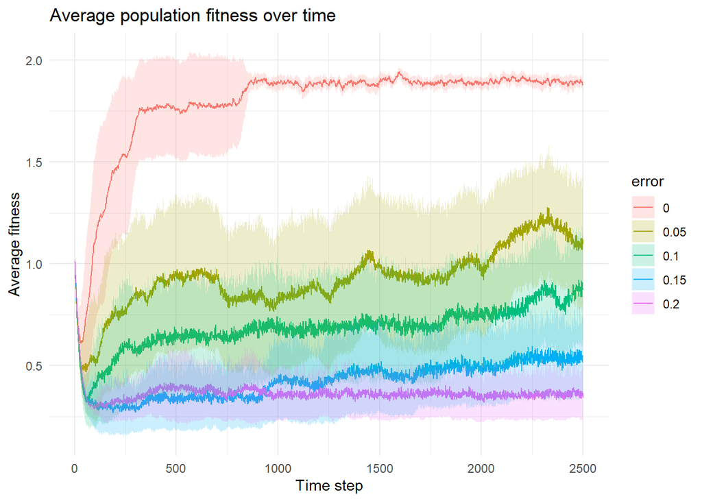

Figure 3: Average population fitness over t for diffrent error rates.

```r
plot_avg_fitness(results$df_population,
                 error)
```

Even at a modest error rate of **5%**, we observe a **significant decline** in average fitness. As the error rate increases, fitness drops further. Note that all simulations with errors have **large confidence intervals (CIs)**. These wide CIs suggest high variability in outcomes across different replications — some worlds may still sustain partial cooperation, while others collapse into full defection. We can easily see this in an OLS:

```r
summary(lm(pop_fit_mean ~ error, data = results$df_population))
```

```
Call:
lm(formula = pop_fit_mean ~ error, data = results$df_population)

Residuals:
     Min       1Q   Median       3Q      Max
-0.89445 -0.17979 -0.03461  0.19816  0.83992

Coefficients:
             Estimate Std. Error t value Pr(>|t|)
(Intercept)  1.505899   0.003839   392.2   <2e-16 ***
error       -6.680093   0.031349  -213.1   <2e-16 ***
---
Signif. codes:  0 '***' 0.001 '**' 0.01 '*' 0.05 '.' 0.1 ' ' 1

Residual standard error: 0.2478 on 12498 degrees of freedom
Multiple R-squared:  0.7842,    Adjusted R-squared:  0.7841
F-statistic: 4.541e+04 on 1 and 12498 DF,  p-value: < 2.2e-16
```

Let’s zoom in on the final steps of the simulation with an error rate of `0.05` (accross different replications):

```r
results$df_strategies |> filter(error == 0.05, step == 2500) |> arrange(desc(strat_share_mean)) |> slice_head(n = 10)
```

```
# A tibble: 10 × 12
    step strat_id strat_share_mean strat_share_sd strat_fit_mean strat_fit_sd
   <int> <chr>               <dbl>          <dbl>          <dbl>        <dbl>
 1  2500 10001             0.638           0.402           1.42        0.419
 2  2500 00001             0.125           0.280           0.294       0.238
 3  2500 00100             0.109           0.269           0.212       0.0756
 4  2500 10101             0.026           0.0514          1.59        0.0681
 5  2500 11111             0.0153          0.0309          0.780       1.21
 6  2500 00101             0.0147          0.0568          0.168      NA
 7  2500 11101             0.0127          0.0258          1.07        1.04
 8  2500 10011             0.01            0.0309          1.07        0.865
 9  2500 00000             0.00533         0.0181          0.147       0.0270
10  2500 11001             0.00533         0.0136          0.791       1.08
# ℹ 6 more variables: strat_weight_fit_mean <dbl>, strat_weight_fit_sd <dbl>,
#   model <chr>, master_seed <dbl>, replications <dbl>, error <dbl>
```

Here, we see that GT remains the most successful strategy on average. However, its **mean fitness has dropped to 1.42** — far from the cooperative optimum of 2. The reason is simple: even when both players use GT, a single misstep can trigger an irreversible chain of mutual defections. Cooperation with these strategies is **fragile** under error.

Now let’s look at the most extreme scenario with a 20% error rate:

```r
results$df_strategies |> filter(error == 0.2, step == 2500) |> arrange(desc(strat_share_mean)) |> slice_head(n = 10)
```

```
# A tibble: 10 × 12
    step strat_id strat_share_mean strat_share_sd strat_fit_mean strat_fit_sd
   <int> <chr>               <dbl>          <dbl>          <dbl>        <dbl>
 1  2500 00000             0.263          0.389           0.283        0.0596
 2  2500 00101             0.193          0.259           0.275        0.0467
 3  2500 10001             0.185          0.377           0.522        0.308
 4  2500 00100             0.169          0.273           0.314        0.0717
 5  2500 00001             0.126          0.302           0.277        0.0417
 6  2500 00010             0.00533        0.0119          0.262        0.0971
 7  2500 10010             0.00533        0.00743         0.187        0.119
 8  2500 10000             0.00467        0.00915         0.212        0.0280
 9  2500 10101             0.00467        0.00834        -0.0589       0.592
10  2500 11010             0.00467        0.00743        -0.0605       0.159
# ℹ 6 more variables: strat_weight_fit_mean <dbl>, strat_weight_fit_sd <dbl>,
#   model <chr>, master_seed <dbl>, replications <dbl>, error <dbl>
```

The picture changes dramatically: aD becomes the dominant strategy. GT falls to third place, and nearly all strategies show **very poor fitness**, hovering far below 1. Cooperation has collapsed under the weight of constant mistakes.

What these results tell us is that **cooperation can survive low error rates**, but it **cannot withstand high error rates** — at least not with the current strategy space.

The problem is that the simple strategies we’re working with — such as GT — are **not designed to tolerate errors**. Once trust is broken, they typically defect forever, unable to distinguish between malice and mistake. They lack mechanisms for **forgiveness**, **error recovery**, or even flexible adaptation in noisy environments.

To address this limitation, we need to equip our agents with the ability to implement **more nuanced behaviors** — strategies that can forgive occasional defections, test trust again, or respond probabilistically. This requires a **richer and more complex strategy space**, where memory and adaptability allow cooperation to persist even in the presence of noise.

We’ll explore this in more depth in the **next in-class session**, where we extend the memory length and introduce strategies capable of resilience under uncertainty.

Before we close, let’s take a moment to explore how the simulation behaves in the presence of **perceptual noise**, rather than behavioral error.

In this setup, agents still intend to follow their strategies correctly, but they may **misperceive** what the other agent did — for example, interpreting cooperation as defection due to observational mistakes or misunderstanding. Here’s the simulation setup:

```r
simulation  <- list(
  model = "with_error",
  replications = 15,
  tbl_parameter = expand.grid(
    noise = seq(0, .2, length.out = 5)
  ),
  master_seed  = 42,
  max_cores    = 15
)

# results <- run_simulation(simulation)
results <- readRDS("../data/abm-pd2/week06_results_03.rds")
```

We begin by visualizing how average population fitness evolves over time under different noise levels (see Figure 4):

**Show R Code (Plot)**

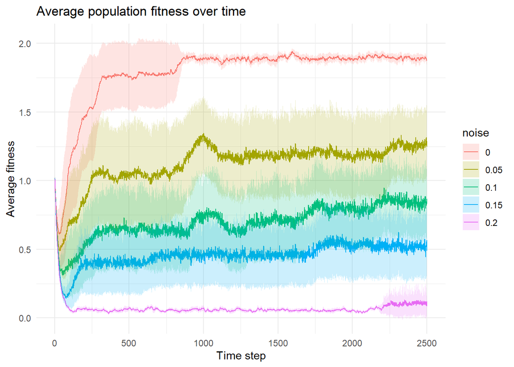

```r
plot_avg_fitness(results$df_population,
                 noise)
```

The result is strikingly similar to what we observed for behavioral error. This isn’t a coincidence. For strategies like Grim Trigger, it makes no practical difference whether an opponent actually defected or was simply perceived to have defected. In both cases, GT interprets the situation as a betrayal — and responds by defecting in all future rounds. The effect is the same: cooperation breaks down.

# 🧩 Conclusion

In this chapter, we took a major step forward by moving beyond idealized, error-free models of interaction. We explored how the introduction of **behavioral** and **perceptual mistakes** changes the dynamics of repeated games — and we saw just how fragile cooperation can be when the world gets messy.

Here’s what we learned:

- **Evolution doesn’t always lead to efficient outcomes**: some systems may settle into inefficient but stable equilibria. A strategy doesn’t need to be optimal to persist — it just needs to resist invasion.
- We distinguished between **misimplementation** (behavioral errors, where agents do something unintended) and **misperception** (communicational noise, where agents misinterpret others’ actions).
- Even **low levels of error or noise** can significantly undermine cooperation, highlighting just how sensitive some strategies are to imperfection.
- Strategies like **Grim Trigger**, while dominant under ideal conditions, prove to be **highly brittle** in noisy environments — often spiraling into permanent defection after a single misstep.
- In contrast, **Always Defect** often re-emerges in high-error settings — not because it yields the best payoffs, but because **stable patterns of cooperation become harder to maintain** when trust is fragile and agents are unforgiving.

# 🏋 Pre-Class Assignment

Before the next session, take some time to engage with the model hands-on. The following exercises will help you consolidate what you’ve learned and begin thinking critically about the dynamics of agent-based models.

1. **[Easy]**  
   According to our simulation, how many **Grim Trigger (GT)** strategies are needed in order to **displace Probe and Peace (PP)** in a population otherwise dominated by PP? Use the experimental setup from class where we gradually increased the number of GT agents and observed their relative fitness.
2. **[Medium]**  
   Using the same simulation framework, test how many **GT agents** are required to achieve **higher fitness than Always Defect (aD)** in a population where all other agents use aD. How many GT agents need to be introduced for cooperation to become evolutionarily viable?

# 🚀 Link to In-Class Material

Here is the link for the in-class material.

## ⚙️ Some Advanced Stuff

Axelrod, Robert, and Douglas Dion. 1988. “The Further Evolution of Cooperation.” *Science* 242 (4884): 1385–90. https://doi.org/10.1126/science.242.4884.1385.

Wu, Jianzhong, and Robert Axelrod. 1995. “How to Cope with Noise in the Iterated Prisoner’s Dilemma.” *Journal of Conflict Resolution* 39 (1): 183–89. https://doi.org/10.1177/0022002795039001008.

## Footnotes

[^1]: A cooperative strategy is any strategy with 1xxx1, where `x` is arbitrary.
[^2]: In theory, a takeover by GT is still possible — but only under extremely rare conditions. If, by pure chance, enough PP agents are repeatedly selected as changers and then happen to mutate into GT, the strategy could eventually reach a critical mass and begin to spread. However, the probability of this sequence of events occurring is vanishingly small.

    To put it differently: if we were to continue running the simulation indefinitely, waiting for such a lucky streak of mutations to unfold, it’s quite likely that the universe would reach its heat death before it ever happened even once. While not technically impossible, in practical terms, this transition is unreachable under the current mutation dynamics and parameter settings. The world is effectively locked into an inefficient yet evolutionarily stable configuration.
[^3]: I made a few more changes than strictly necessary compared to the original version of the code — in particular, I renamed several variables. This wasn’t just for the sake of change, but for educational clarity. By giving variables more descriptive names, it becomes easier to follow the logic of the simulation and understand exactly what each part of the code is doing.

## Copyright

Copyright Sascha Grehl, 2025. All Rights Reserved